# linear model

Armen Khatchatrian

Fall 2026

Null Hypothesis (H₀): Adding horsepower to the regression model containing displacement does not significantly improve the prediction of miles per gallon.

Alternative Hypothesis (Hₐ): Adding horsepower to the regression model containing displacement significantly improves the prediction of miles per gallon.

Read about the data from the website where it is staged.

Form three regression models; Model1 is mpg~disp, Model2 is mpg~hp, and Model3 is mpg~disp+hp.

For each model find a 95% prediction interval of mpg given a value of 183 for displacement and 250 for hp.

After all three models have been constructed, compare Model1 with Model3 using anova. Document the comparison the markdown document,

As usual, push the project up to your github account and submit the URL to canvas as link.

```r
data(mtcars)
myData=mtcars
```

## Model 1 mpg~disp

### scatterplot

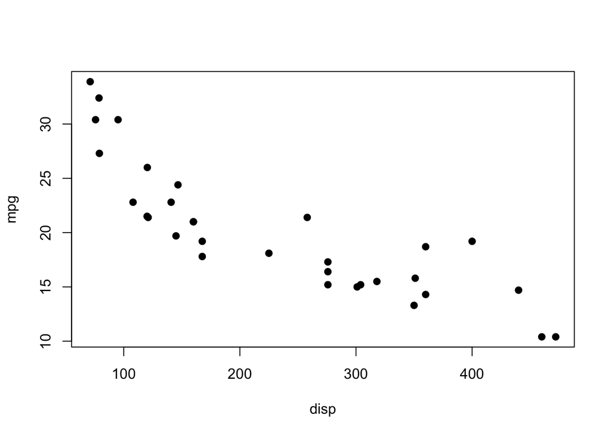

```r
plot(mpg~disp,data=mtcars, pch=19)
```

This scatterplot shows that as displacement increases mpg decreases.

### Numerical results

```r
cor(mtcars$mpg, mtcars$disp)
```

```
## [1] -0.8475514
```

The correlation coefficient is approximately -0.848, indicating a strong negative linear relationship between engine displacement and miles per gallon. As engine displacement increases, fuel efficiency generally decreases.

### Inferential (Build model.1)

```r
model.1 <- lm(mpg~disp,data=mtcars)
summary.lm(model.1)
```

```
##
## Call:
## lm(formula = mpg ~ disp, data = mtcars)
##
## Residuals:
##     Min      1Q  Median      3Q     Max
## -4.8922 -2.2022 -0.9631  1.6272  7.2305
##
## Coefficients:
##              Estimate Std. Error t value Pr(>|t|)
## (Intercept) 29.599855   1.229720  24.070  < 2e-16 ***
## disp        -0.041215   0.004712  -8.747 9.38e-10 ***
## ---
## Signif. codes:  0 '***' 0.001 '**' 0.01 '*' 0.05 '.' 0.1 ' ' 1
##
## Residual standard error: 3.251 on 30 degrees of freedom
## Multiple R-squared:  0.7183, Adjusted R-squared:  0.709
## F-statistic: 76.51 on 1 and 30 DF,  p-value: 9.38e-10
```

The regression model shows that displacement is a statistically significant predictor of miles per gallon. The model explains approximately 71.8% of the variation in fuel efficiency. The negative regression coefficient indicates that vehicles with larger engine displacement generally have lower fuel efficiency.

#### Predict at target point

```r
newdata.1 <- data.frame(disp = 183)

predict(model.1,
        newdata = newdata.1,
        interval = "prediction",
        level = 0.95)
```

```
##        fit      lwr      upr
## 1 22.05749 15.29856 28.81642
```

For a vehicle with an engine displacement of 183 cubic inches, Model 1 predicts a fuel efficiency of approximately 22.06 miles per gallon. The 95% prediction interval ranges from 15.30 to 28.82 miles per gallon. This interval provides an estimated range for the fuel efficiency of an individual vehicle with this displacement.